# Unit Project 2

Biol 101 February 6, 2026 Marleen Zaarte

### Lecture 06

# Removing missing data for plotting

```r
penguins <- penguins %>%
  drop_na(flipper_length_mm, body_mass_g, bill_length_mm, bill_depth_mm, sex)
```

# Q1: Bar plots

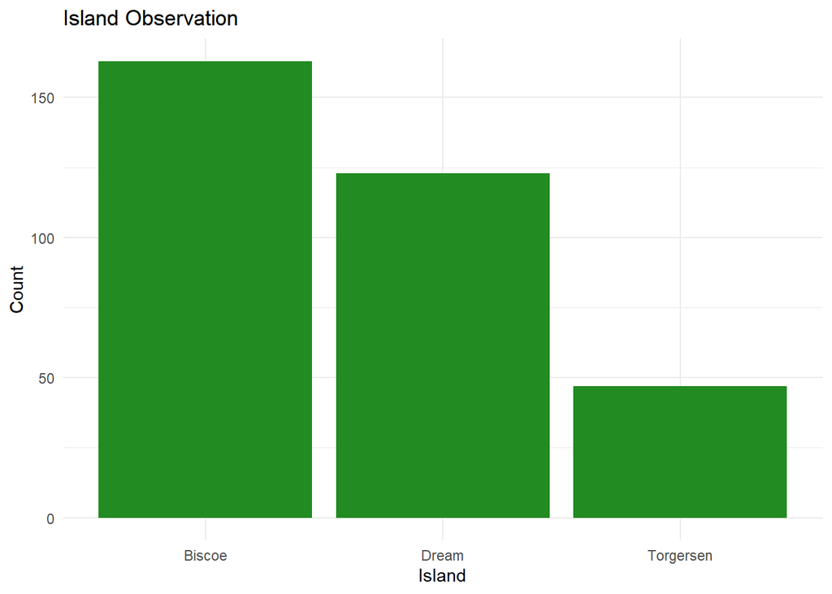

```r
ggplot(penguins, aes(x = island)) +
  geom_bar(fill = "forestgreen") +
  labs(title = "Island Observation", x = "Island", y = "Count") +
  theme_minimal()
```

# Q2: Histograms

How the bins change the appearance?  
Answer: As the bin number increases, there’s more space between each bin the body mass is more clear at 60.

How distribution differs in species?  
Answer: The body mass of the Adelie species seem to be lower compared to the Gentoo species. Their distribution is different in terms of which way they are centered on the histogram.

Do they have the same approximate mean? Answer: They do not seem to have a similar mean.

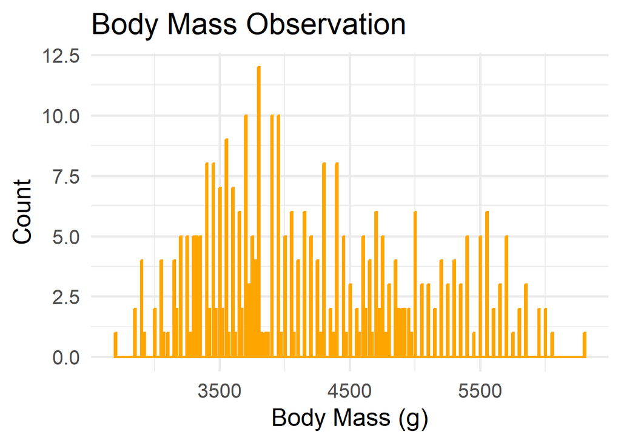

```r
ggplot(penguins, aes(x = body_mass_g)) +
  geom_histogram(binwidth = 10, fill = "seagreen", color = "orange") +
  labs(title = "Body Mass Observation", x = "Body Mass (g)", y = "Count") +
  theme_minimal(base_size = 20)
```

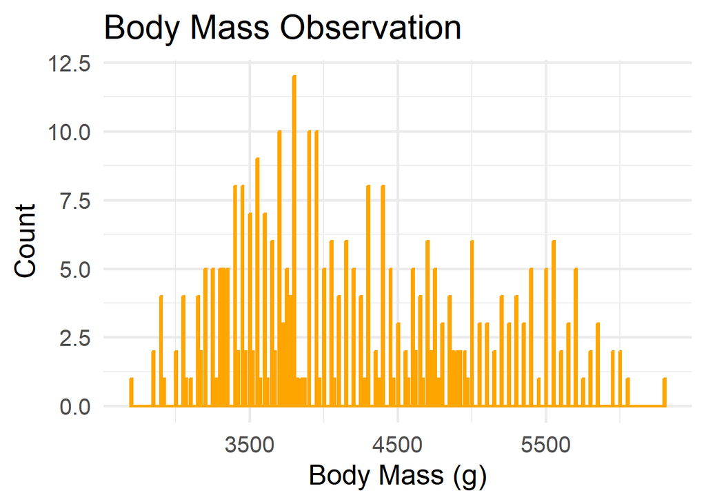

```r
ggplot(penguins, aes(x = body_mass_g)) +
  geom_histogram(binwidth = 10, fill = "seagreen", color = "orange") +
  labs(title = "Body Mass Observation", x = "Body Mass (g)", y = "Count") +
  theme_minimal(base_size = 20)
```

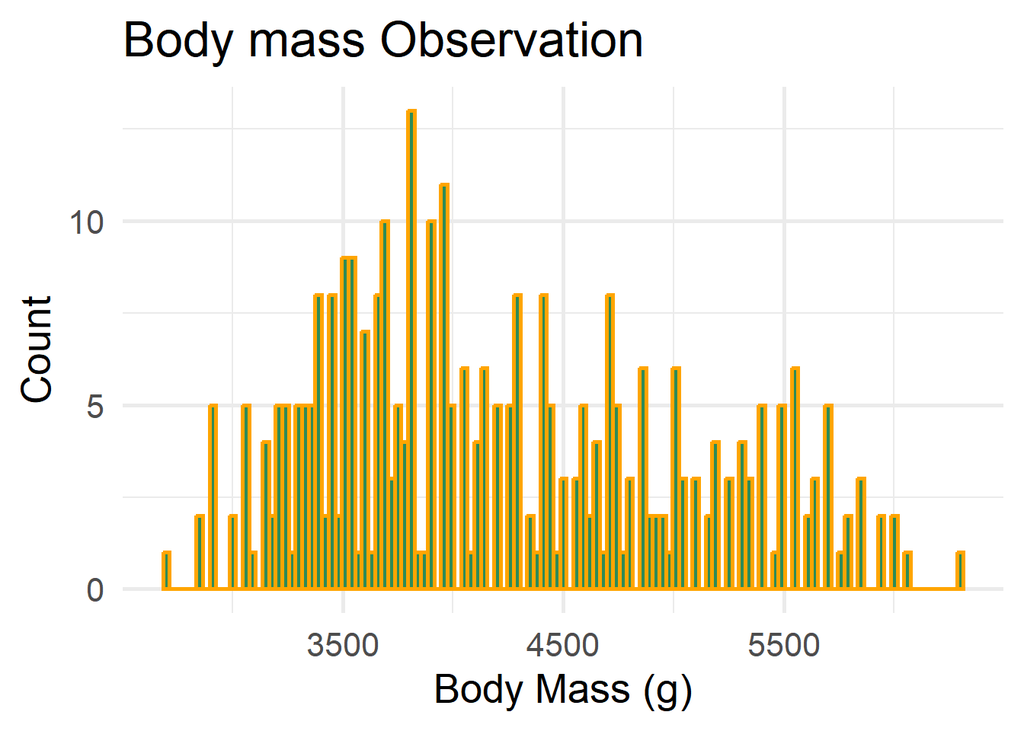

```r
ggplot(penguins, aes(x = body_mass_g)) +
  geom_histogram(binwidth = 30, fill = "seagreen", color = "orange") +
  labs(title = "Body mass Observation", x = "Body Mass (g)", y = "Count") +
  theme_minimal(base_size = 20)
```

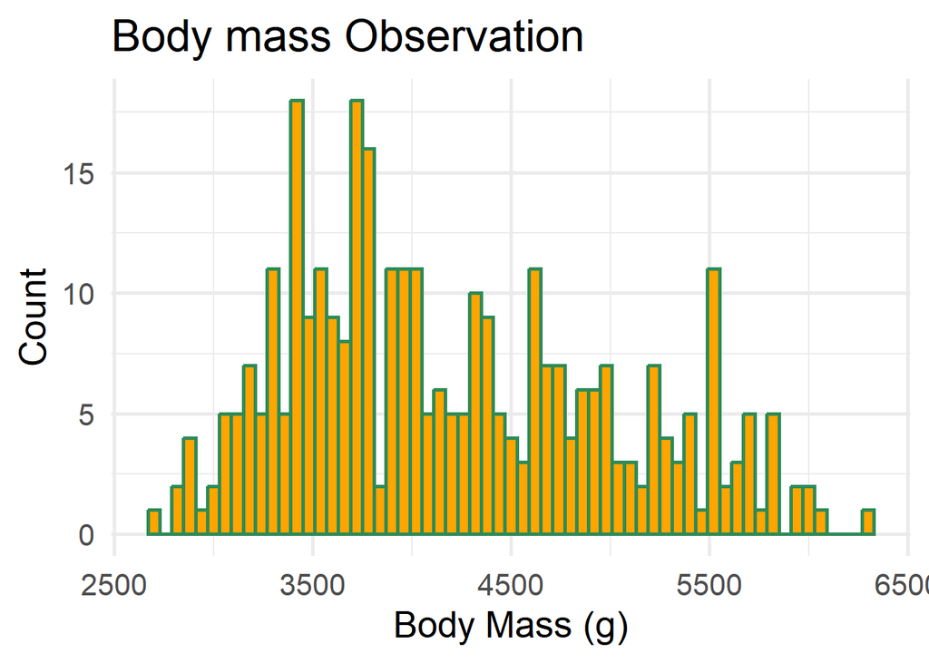

```r
ggplot(penguins, aes(x = body_mass_g)) +
  geom_histogram(binwidth = 60, fill = "orange", color = "seagreen") +
  labs(title = "Body mass Observation", x = "Body Mass (g)", y = "Count") +
  theme_minimal(base_size = 20)
```

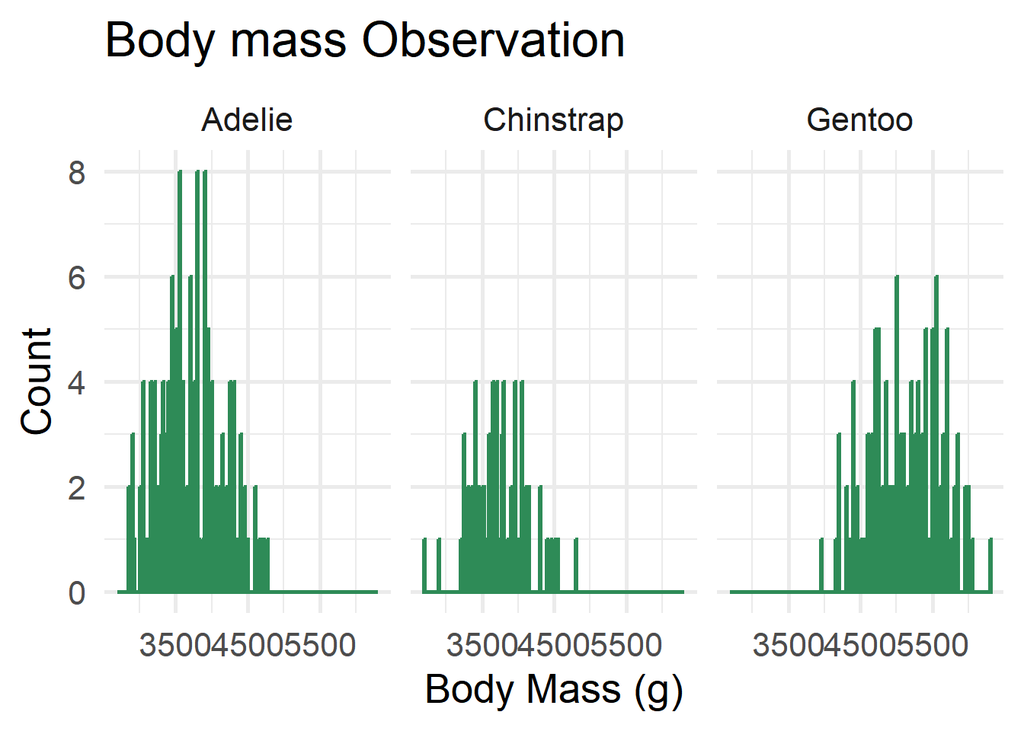

```r
ggplot(penguins, aes(x = body_mass_g)) +
  geom_histogram(binwidth = 10, fill = "orange", color = "seagreen") +
  facet_wrap(~ species) +
  labs(title = "Body mass Observation", x = "Body Mass (g)", y = "Count") +
  theme_minimal(base_size = 20)
```

# Q3: Boxplots

Which species has the longest flippers? Answer: The Gentoo species has a value of around 215 mm in length.

Do males and females differ? Answer: Yes, they differ by body mass.

Does fill = species help with readability? Answer: No. The plot got smaller and data is not visable.

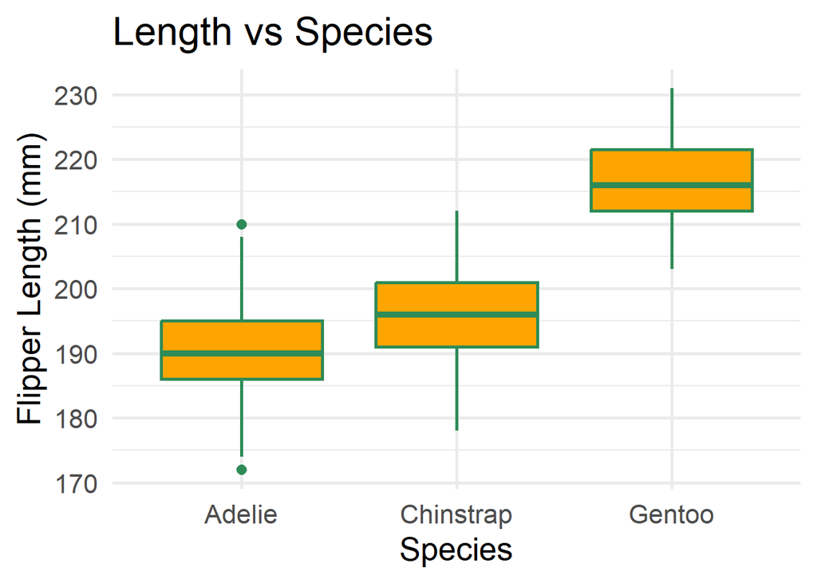

```r
# Flipper length by species

ggplot(penguins, aes(y = flipper_length_mm, x = species, fill = species, color = species)) +
  geom_boxplot(fill = "orange", color = "seagreen") +
  labs(title = "Length vs Species", y = "Flipper Length (mm)", x = "Species") +
  theme_minimal(base_size = 20) + scale_color_brewer(palette = "Set1") + theme(legend.position = "none")
```

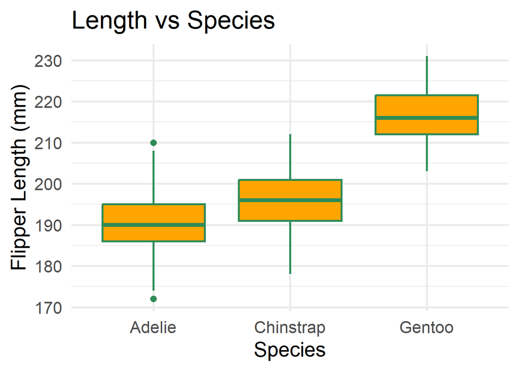

```r
ggplot(penguins, aes(y = flipper_length_mm, x = species, fill = species, color = species)) +
  geom_boxplot(fill = "orange", color = "seagreen") +
  labs(title = "Length vs Species", y = "Flipper Length (mm)", x = "Species") +
  theme_minimal(base_size = 20) + scale_color_brewer(palette = "Set1") + theme(legend.position = "none")
```

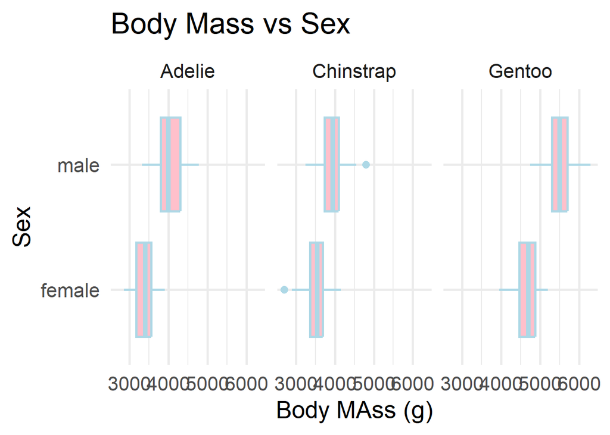

```r
# Body mass by sex
ggplot(penguins, aes(x = body_mass_g, y = sex, color = species, fill = species)) +
  geom_boxplot(fill = "pink", color = "lightblue") +
  facet_wrap(~ species) +
  labs(title = "Body Mass vs Sex", x = "Body MAss (g)", y = "Sex") +
  theme_minimal(base_size = 20) + scale_color_brewer(palette = "Set1") + theme(legend.position = "none")
```

# Q 4: Scatterplots

Is the relationship pos, neg, or unclear? Answer: The relationship seems unclear.

Does color = species change the interpretation? Answer: Yes, now there is a specific color for each species.

Does the line fit the data after adding geom_smooth(method = “lm”)? Answer: Yes, It does.

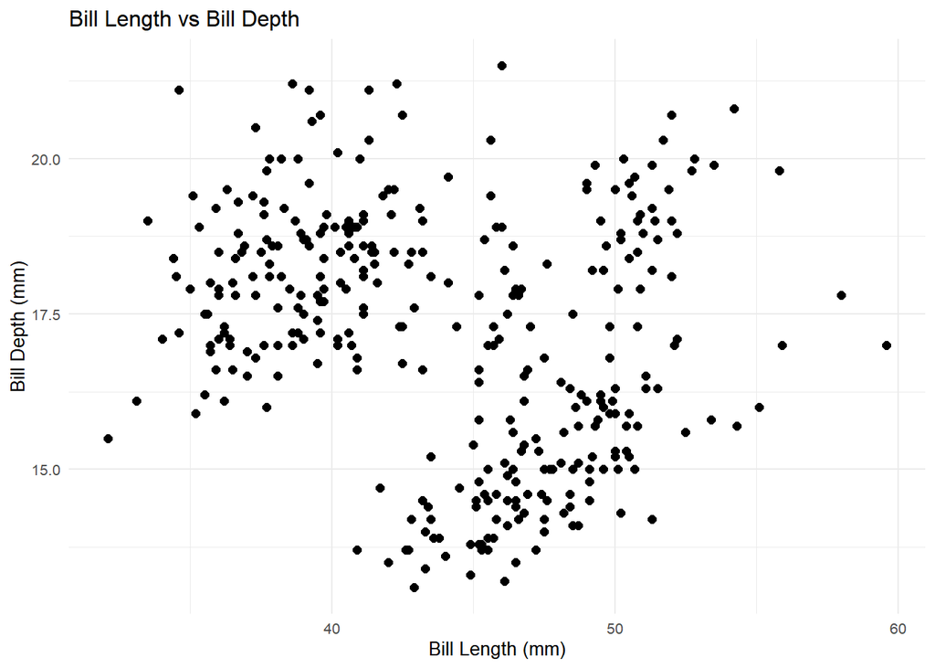

```r
ggplot(penguins, aes(x = bill_length_mm, y = bill_depth_mm)) +
  geom_point(size =2) + labs(title = "Bill Length vs Bill Depth", x = "Bill Length (mm)", y = "Bill Depth (mm)") + theme_minimal(base_size =  10)
```

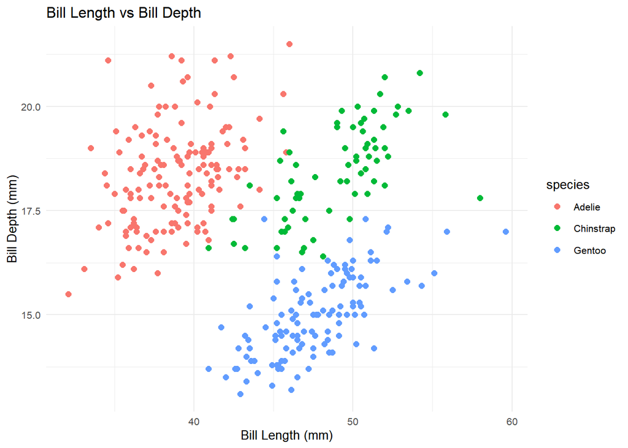

```r
ggplot(penguins, aes(x = bill_length_mm, y = bill_depth_mm, color = species)) +
  geom_point(size =2) + labs(title = "Bill Length vs Bill Depth", x = "Bill Length (mm)", y = "Bill Depth (mm)") + theme_minimal(base_size =  10)
```

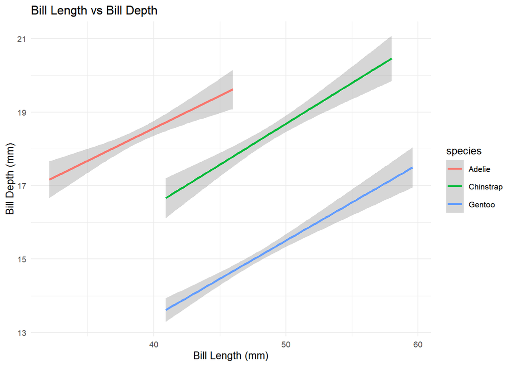

```r
ggplot(penguins, aes(x = bill_length_mm, y = bill_depth_mm, color = species)) +
  geom_smooth(method = "lm") + labs(title = "Bill Length vs Bill Depth", x = "Bill Length (mm)", y = "Bill Depth (mm)") + theme_minimal(base_size =  10)
```

# Q 5: Faucet Scatter Plots

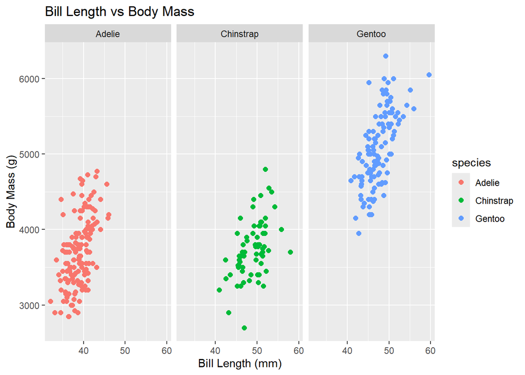

```r
ggplot(penguins, aes(x = bill_length_mm, y = body_mass_g, color = species)) +
  geom_point(size = 2) +
  facet_wrap(~species) +
  labs(title = "Bill Length vs Body Mass", x = "Bill Length (mm)", y = "Body Mass (g)")
```

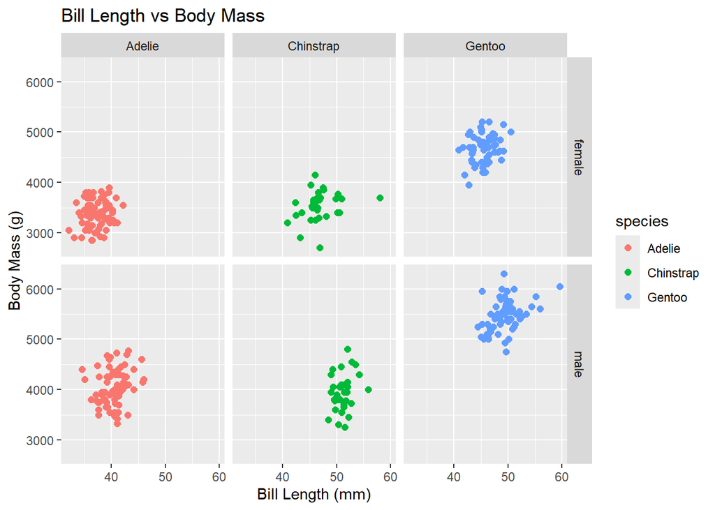

```r
ggplot(penguins, aes(x = bill_length_mm, y = body_mass_g, color = species)) +
  geom_point(size = 2) +
  facet_grid(sex ~ species) +
  labs(title = "Bill Length vs Body Mass", x = "Bill Length (mm)", y = "Body Mass (g)")
```

# Q6: My figure plotting bill depth vs flipper length of each species

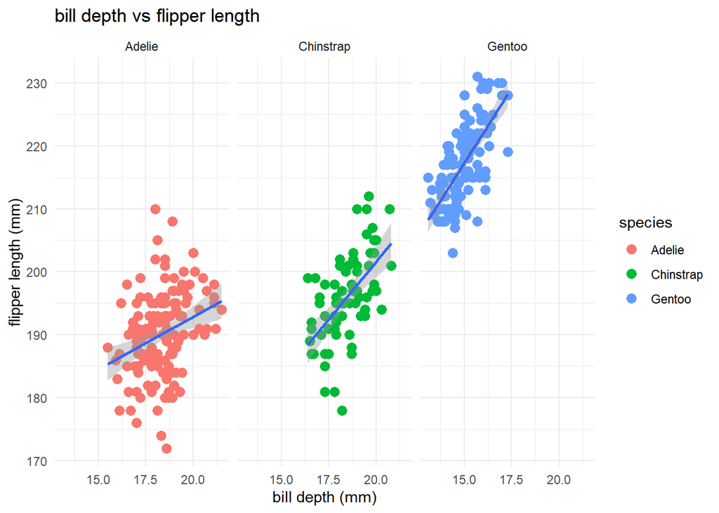

```r
ggplot(penguins, aes(x = bill_depth_mm, y = flipper_length_mm)) + geom_point(aes(color = species), size = 3) + geom_smooth(method = "lm") + facet_wrap(~species) + labs(title = "bill depth vs flipper length", x = "bill depth (mm)", y = "flipper length (mm)", color = "species") + theme_minimal()
```

# Q7: Reflection The most fun or interesting part of this exercise is learning of many packages that exist for color or for decorating the backgrounds of theseplots. The most confusing was part was creating the box plots so I messed around a little and although I may have added a bit more than just one plot for each question, I hope I somewhat did alright in terms of what was asked. I definetly will practice on my free time and see if I get the hang of it.

### Lecture 07

# Messy Penguins File

```r
penguins_messy <- read.csv("penguins_messy.csv")
```

# Q1: Write what each one does in terms of commands:

```r
str_detect(penguins_messy$species_messy, "adelie")
```

```
##   [1]  TRUE  TRUE  TRUE  TRUE  TRUE  TRUE  TRUE  TRUE  TRUE  TRUE  TRUE  TRUE
##  [13]  TRUE  TRUE  TRUE  TRUE  TRUE  TRUE  TRUE  TRUE  TRUE  TRUE  TRUE  TRUE
##  [25]  TRUE  TRUE  TRUE  TRUE  TRUE  TRUE  TRUE  TRUE  TRUE  TRUE  TRUE  TRUE
##  [37]  TRUE  TRUE  TRUE  TRUE  TRUE  TRUE  TRUE  TRUE  TRUE  TRUE  TRUE  TRUE
##  [49]  TRUE  TRUE  TRUE  TRUE  TRUE  TRUE  TRUE  TRUE  TRUE  TRUE  TRUE  TRUE
##  [61]  TRUE  TRUE  TRUE  TRUE  TRUE  TRUE  TRUE  TRUE  TRUE  TRUE  TRUE  TRUE
##  [73]  TRUE  TRUE  TRUE  TRUE  TRUE  TRUE  TRUE  TRUE  TRUE  TRUE  TRUE  TRUE
##  [85]  TRUE  TRUE  TRUE  TRUE  TRUE  TRUE  TRUE  TRUE  TRUE  TRUE  TRUE  TRUE
##  [97]  TRUE  TRUE  TRUE  TRUE  TRUE  TRUE  TRUE  TRUE  TRUE  TRUE  TRUE  TRUE
## [109]  TRUE  TRUE  TRUE  TRUE  TRUE  TRUE  TRUE  TRUE  TRUE  TRUE  TRUE  TRUE
## [121]  TRUE  TRUE  TRUE  TRUE  TRUE  TRUE  TRUE  TRUE  TRUE  TRUE  TRUE  TRUE
## [133]  TRUE  TRUE  TRUE  TRUE  TRUE  TRUE  TRUE  TRUE  TRUE  TRUE  TRUE  TRUE
## [145]  TRUE  TRUE  TRUE  TRUE  TRUE  TRUE  TRUE  TRUE FALSE FALSE FALSE FALSE
## [157] FALSE FALSE FALSE FALSE FALSE FALSE FALSE FALSE FALSE FALSE FALSE FALSE
## [169] FALSE FALSE FALSE FALSE FALSE FALSE FALSE FALSE FALSE FALSE FALSE FALSE
## [181] FALSE FALSE FALSE FALSE FALSE FALSE FALSE FALSE FALSE FALSE FALSE FALSE
## [193] FALSE FALSE FALSE FALSE FALSE FALSE FALSE FALSE FALSE FALSE FALSE FALSE
## [205] FALSE FALSE FALSE FALSE FALSE FALSE FALSE FALSE FALSE FALSE FALSE FALSE
## [217] FALSE FALSE FALSE FALSE FALSE FALSE FALSE FALSE FALSE FALSE FALSE FALSE
## [229] FALSE FALSE FALSE FALSE FALSE FALSE FALSE FALSE FALSE FALSE FALSE FALSE
## [241] FALSE FALSE FALSE FALSE FALSE FALSE FALSE FALSE FALSE FALSE FALSE FALSE
## [253] FALSE FALSE FALSE FALSE FALSE FALSE FALSE FALSE FALSE FALSE FALSE FALSE
## [265] FALSE FALSE FALSE FALSE FALSE FALSE FALSE FALSE FALSE FALSE FALSE FALSE
## [277] FALSE FALSE FALSE FALSE FALSE FALSE FALSE FALSE FALSE FALSE FALSE FALSE
## [289] FALSE FALSE FALSE FALSE FALSE FALSE FALSE FALSE FALSE FALSE FALSE FALSE
## [301] FALSE FALSE FALSE FALSE FALSE FALSE FALSE FALSE FALSE FALSE FALSE FALSE
## [313] FALSE FALSE FALSE FALSE FALSE FALSE FALSE FALSE FALSE FALSE FALSE FALSE
## [325] FALSE FALSE FALSE FALSE FALSE FALSE FALSE FALSE FALSE FALSE FALSE FALSE
## [337] FALSE FALSE FALSE FALSE FALSE FALSE FALSE FALSE
```

# This one detects for the adelie penguin species within the messy data by saying

# the ones tht are adelie are TRUE.

```r
str_replace_all(penguins_messy$sex_messy, "\\?", "")
```

```
##   [1] "M" "f" "f" NA  "f" "M" "f" "M" NA  NA  NA  NA  "f" "M" "M" "f" "f" "M"
##  [19] "f" "M" "f" "M" "f" "M" "M" "f" "M" "f" "f" "M" "f" "M" "f" "M" "f" "M"
##  [37] "M" "f" "f" "M" "f" "M" "f" "M" "f" "M" "M" NA  "f" "M" "f" "M" "f" "M"
##  [55] "f" "M" "f" "M" "f" "M" "f" "M" "f" "M" "f" "M" "f" "M" "f" "M" "f" "M"
##  [73] "f" "M" "f" "M" "f" "M" "f" "M" "f" "M" "f" "M" "f" "M" "M" "f" "M" "f"
##  [91] "f" "M" "f" "M" "f" "M" "f" "M" "f" "M" "f" "M" "f" "M" "f" "M" "f" "M"
## [109] "f" "M" "f" "M" "f" "M" "f" "M" "f" "M" "f" "M" "f" "M" "f" "M" "f" "M"
## [127] "f" "M" "f" "M" "f" "M" "f" "M" "f" "M" "f" "M" "f" "M" "f" "M" "f" "M"
## [145] "f" "M" "M" "f" "f" "M" "f" "M" "f" "M" "f" "M" "M" "f" "f" "M" "f" "M"
## [163] "f" "M" "f" "M" "f" "M" "f" "M" "f" "M" "M" "f" "f" "M" "f" "M" NA  "M"
## [181] "f" "M" "M" "f" "f" "M" "f" "M" "f" "M" "f" "M" "f" "M" "f" "M" "M" "f"
## [199] "f" "M" "f" "M" "f" "M" "f" "M" "f" "M" "f" "M" "f" "M" "f" "M" "f" "M"
## [217] "f" "M" NA  "M" "f" "M" "f" "M" "M" "f" "f" "M" "f" "M" "f" "M" "f" "M"
## [235] "f" "M" "f" "M" "f" "M" "f" "M" "f" "M" "f" "M" "f" "M" "M" "f" "f" "M"
## [253] "f" "M" "f" "M" NA  "M" "f" "M" "f" "M" "f" "M" "f" "M" "f" "M" NA  "M"
## [271] "f" NA  "f" "M" "f" "M" "f" "M" "M" "f" "M" "f" "f" "M" "f" "M" "f" "M"
## [289] "f" "M" "f" "M" "M" "f" "f" "M" "f" "M" "f" "M" "f" "M" "f" "M" "f" "M"
## [307] "f" "M" "f" "M" "M" "f" "f" "M" "f" "M" "M" "f" "M" "f" "f" "M" "f" "M"
## [325] "M" "f" "f" "M" "f" "M" "f" "M" "f" "M" "M" "f" "M" "f" "f" "M" "f" "M"
## [343] "M" "f"
```

```r
str_squish(penguins_messy$island_messy)
```

```
##   [1] "Torgersen" "Torgersen" "Torgersen" "Torgersen" "Torgersen" "Torgersen"
##   [7] "Torgersen" "Torgersen" "Torgersen" "Torgersen" "Torgersen" "Torgersen"
##  [13] "Torgersen" "Torgersen" "Torgersen" "Torgersen" "Torgersen" "Torgersen"
##  [19] "Torgersen" "Torgersen" "BIS-COE"   "BIS-COE"   "BIS-COE"   "BIS-COE"
##  [25] "BIS-COE"   "BIS-COE"   "BIS-COE"   "BIS-COE"   "BIS-COE"   "BIS-COE"
##  [31] "Dream"     "Dream"     "Dream"     "Dream"     "Dream"     "Dream"
##  [37] "Dream"     "Dream"     "Dream"     "Dream"     "Dream"     "Dream"
##  [43] "Dream"     "Dream"     "Dream"     "Dream"     "Dream"     "Dream"
##  [49] "Dream"     "Dream"     "BIS-COE"   "BIS-COE"   "BIS-COE"   "BIS-COE"
##  [55] "BIS-COE"   "BIS-COE"   "BIS-COE"   "BIS-COE"   "BIS-COE"   "BIS-COE"
##  [61] "BIS-COE"   "BIS-COE"   "BIS-COE"   "BIS-COE"   "BIS-COE"   "BIS-COE"
##  [67] "BIS-COE"   "BIS-COE"   "Torgersen" "Torgersen" "Torgersen" "Torgersen"
##  [73] "Torgersen" "Torgersen" "Torgersen" "Torgersen" "Torgersen" "Torgersen"
##  [79] "Torgersen" "Torgersen" "Torgersen" "Torgersen" "Torgersen" "Torgersen"
##  [85] "Dream"     "Dream"     "Dream"     "Dream"     "Dream"     "Dream"
```

[output cut: 43 more lines]

This one removes any white spaces in the isalnd column and makes the data into a compact string.

# Q2: The number of rows with valid ids is 316.

```r
penguins_messy <- penguins_messy %>%
  mutate(valid_id = str_detect(sample_id, "PAL-[0-9]{3}"))

penguins_messy %>%
  pull(valid_id) %>%
  sum()
```

```
## [1] 316
```

# Q3: Filter to keep rows where valid_id is TRUE

```r
penguins_mess <- penguins_messy %>%
  filter(valid_id)
```

# Q4: Added two new columns

```r
penguins_messy <- penguins_messy %>%
  mutate(file_date = str_extract(file_name, "^[0-9]{4}-[0-9]{2}-[0-9]{2}"), file_id = str_extract(file_name, "PAL-042"))

print(penguins_messy$file_date[1:10])
```

```
##  [1] "2024-01-14" "2024-01-17" "2024-01-08" "2024-01-26" "2024-01-06"
##  [6] "2024-01-08" "2024-01-08" "2024-01-19" "2024-01-14" "2024-01-24"
```

```r
print(penguins_messy$file_id[1:10])
```

```
##  [1] NA NA NA NA NA NA NA NA NA NA
```

# Q5: New island column with possible values: Torgersen, BIS-COE, Dream

```r
penguins_messy <- penguins_messy %>%
  mutate(island = str_squish(island_messy))
unique(penguins_messy$island)
```

```
## [1] "Torgersen" "BIS-COE"   "Dream"
```

# Q6

```r
penguins_messy <- penguins_messy %>%
  mutate(sex = str_messy_clean <- str_replace_all(sex_messy, "\\?", ""), sex = str_to_upper(sex))
unique(penguins_messy$sex)
```

```
## [1] "M" "F" NA
```

# Q7

```r
penguins_messy <- penguins_messy %>%
  mutate(bill_mm = str_replace_all(notes, "(.*bill=)|mm", ""), bill_mm = as.numeric(bill_mm))
```

# Q8: Reflection

Ok first I’ll start with the difficulty. I had trouble figuring out how to mutate and create the valid_id column. It took me several repeated tries and readings to figure out the format of how to creat it given its true for that particular format. After that though, It was basiclaly using mutate to create new columns each asked with different tasks such as replacing or removing. What I found interesting was the use of regex. I didn’t know that these symbols used together can be used to find specific things in strings. It’s kind of fun deciphering it.

### Lecture 08

library(dplyr)

# Q1

```r
names(penguins_messy)
```

```
##  [1] "species_messy" "island_messy"  "sex_messy"     "sample_id"
##  [5] "file_name"     "notes"         "valid_id"      "file_date"
##  [9] "file_id"       "island"        "sex"           "bill_mm"
```

```r
penguins_clean <- penguins_messy %>%
  drop_na(bill_mm, sex)
```

# Q2: Having duplicats can skew your statostical data or it could hold more ‘weight’ in terms of how much data there is.

```r
penguins_dup <- penguins_clean %>%
  bind_rows(slice_sample(penguins_clean, n = 30, replace = TRUE))
nrow(penguins_dup)
```

```
## [1] 363
```

```r
total_rows <- nrow(penguins_dup)
print(paste("Total Pen_dup Rows", total_rows))
```

```
## [1] "Total Pen_dup Rows 363"
```

```r
total_distinct <- nrow(distinct(penguins_dup))
print(paste("Total Pen_dup rows after removing dups", total_distinct))
```

```
## [1] "Total Pen_dup rows after removing dups 333"
```

# Q3: 3 colums are in the resulting data frame

```r
penguins_numeric <- penguins_clean %>%
  select(island, sex, where(is.numeric))
ncol(penguins_numeric)
```

```
## [1] 3
```

# Q4

```r
bill_cols <- penguins_clean %>%
  select(starts_with("bill"))
mm_cols <- penguins_clean %>%
  select(ends_with("_mm"))
bill_flipper_cols <- penguins_clean %>%
  select(matches("^(bill|flipper)"))
```

# Q5: It’s better to use across than typing it all out because it takes less time writing it all out and its easy to understand.

```r
#penguins_summary <- penguins_clean %>%
 # group_by(species) %>%
 # summaries(across(where(is.numeric), mean, na.rm = TRUE))
```

# Q6

```r
penguins_clean <- penguins_clean %>%
  mutate(bill_length = case_when( bill_mm < 50 ~ "medium", bill_mm < 40 ~ "short", bill_mm >= 50 ~ "long"))
```

# Q7:

```r
#instrument_meta <- tibble(
#  instrument_id = c("caliper_A", "caliper_B", "caliper_C"),
#  calibration_mm = c(0.2, 0.5, 1.0),
 # manufacturer = c("Mitutoyo", "Fowler", "Generic")
#)
#penguins_instrumented <- penguins_clean %>%
 # drop_na(bill_mm) %>%
 # mutate(instrument_id = case_when(year == 2007 ~ "caliper_A", year == 2008 ~ "caliper_B", year #== 2009 ~ "calipaer_C")) %>%
 # left_join(instrument_met, by = "instrument_id")
```

# Q8: Reflection

The hard part of this one was the last question where I had to write out each year in the case_when function. For some reason, it kept making the last year 2009 all green characters so I had to rewrite it all over again. Aside that, it just took a while to actually understand the formats and what I was looking for. The tricky part was making sure I didn’t get erros when I knit and due to that I learned that r chunks require unique names and duplicate names are not allowed. That’s what I found interesting.

[output not shown]